# Projekt VAR

Ewelina Nieć

2024-03-25

# Cel projektu

Celem projektu jest stworzenie modelu VAR, stanowiącego bazę dla analizy przyczynowości w sensie Grangera celem uzyskania informacji jak poszczególne rynki wpływają na siebie (o ile wpływają).

Badanie opiera się na danych, które zakresem obejmują dwa okresy:

- od stycznia 2016 roku do grudnia 2019 roku - okres przed COVID
- od stycznie 2020 roku do grudnia 2023 roku - okres i trakcie i po COVID

Zbiór danych składa się z:

• cen zamknięcia polskiej giełdy - WIG

• cen zamknięcia ukraińskiej giełdy - WIG_Ukraina

• cen zamknięcia czeskiej giełdy - PX

• cen zamknięcia niemieckiej giełdy - DAX

• cen ropy naftowej - ROPA

• cen obligacji

## Okres przed Covid

### Przygotowanie danych

**Wczytanie plików**

```r
# Polska
WIG_przed <- read_csv("Dane/WIG_przed.csv")
WIG_przed <- WIG_przed[,c(1,5)]
colnames(WIG_przed) <- c('data','WIG_przed')

ZLOTY_przed <- read_csv("Dane/ZLOTY_przed.csv")
ZLOTY_przed <- ZLOTY_przed[,c(1,5)]
colnames(ZLOTY_przed) <- c('data','ZLOTY_przed')



# Ukraina
WIG_ukraina_przed <- read_csv("Dane/WIG_ukraina_przed.csv")
WIG_ukraina_przed <- WIG_ukraina_przed[,c(1,5)]
colnames(WIG_ukraina_przed) <- c('data','WIG_ukraina_przed')

HRYWNA_przed <- read_csv("Dane/HRYWNA_przed.csv")
HRYWNA_przed <- HRYWNA_przed[,c(1,5)]
HRYWNA_przed[,2] <- 1/HRYWNA_przed[,2]
colnames(HRYWNA_przed) <- c('data','HRYWNA_przed')


# Czechy
PX_przed <- read_csv("Dane/PX_przed.csv")
PX_przed <- PX_przed[,c(1,5)]
colnames(PX_przed) <- c('data','PX_przed')

KORONA_przed <- read_csv("Dane/KORONA_przed.csv")
KORONA_przed <- KORONA_przed[,c(1,5)]
colnames(KORONA_przed) <- c('data','KORONA_przed')


# Niemcy
DAX_przed <- read_csv("Dane/DAX_przed.csv")
DAX_przed <- DAX_przed[,c(1,5)]
colnames(DAX_przed) <- c('data','DAX_przed')

EURO_przed <- read_csv("Dane/EURO_przed.csv")
EURO_przed <- EURO_przed[,c(1,5)]
colnames(EURO_przed) <- c('data','EURO_przed')


# ropa
ROPA_przed <- read_delim("C:/Users/eweli/OneDrive/Desktop/AW/projekt2/dane/ROPA_przed.csv",
    delim = ";", escape_double = FALSE, trim_ws = TRUE)
ROPA_przed <- ROPA_przed[,c(1,5)]
colnames(ROPA_przed) <- c('data','ROPA_przed')

# obligacje
obligacje_przed <- read_csv("Dane/obligacje_przed.csv")
obligacje_przed <- obligacje_przed[,c(1,5)]
colnames(obligacje_przed) <- c('data','obligacje_przed')
```

**Przewalutowanie na dolary**

```r
# POLSKA - WIG PLN na USD
df <- merge(x=WIG_przed,y=ZLOTY_przed,
          by="data", all.x=TRUE)
WIG_przed_USD <- data.frame("data" = df[1], df[2]*df[3])
rm(df,WIG_przed)

# UKRAINA - WIG Ukraina UAH na USD
df <- merge(x=WIG_ukraina_przed,y=HRYWNA_przed,
          by="data", all.x=TRUE)
WIG_ukraina_przed_USD <- data.frame("data" = df[1], df[2]*df[3])
rm(df,WIG_ukraina_przed,HRYWNA_przed)

# Czechy PX CZK na USD
df <- merge(x=PX_przed,y=KORONA_przed,
          by="data", all.x=TRUE)
PX_przed_USD <- data.frame("data" = df[1], df[2]*df[3])
rm(df,PX_przed,KORONA_przed)

# Niemcy DAX EUR na USD
df <- merge(x=DAX_przed,y=EURO_przed,
          by="data", all.x=TRUE)
DAX_przed_USD <- data.frame("data" = df[1], df[2]*df[3])
rm(df,DAX_przed,EURO_przed)

# Ropa
ROPA_przed <- ROPA_przed[complete.cases(ROPA_przed),]
ROPA_przed$data <- as.Date(ROPA_przed$data, format = "%d.%m.%Y")

# Obligacje PLN na USD
df <- merge(x=obligacje_przed,y=ZLOTY_przed,
          by="data", all.x=TRUE)
obligacje_przed_USD <- data.frame("data" = df[1], df[2]*df[3])
rm(df,obligacje_przed,ZLOTY_przed)
```

**Łączenie wszystkich tabel w jedną**

```r
# przed
df_przed <- WIG_przed_USD %>% full_join(WIG_ukraina_przed_USD, by = "data")
df_przed <- df_przed %>% full_join(PX_przed_USD, by = "data")
df_przed <- df_przed %>% full_join(DAX_przed_USD, by = "data")
df_przed <- df_przed %>% full_join(ROPA_przed, by = "data")
df_przed <- df_przed %>% full_join(obligacje_przed_USD, by = "data")

rm(WIG_przed_USD, WIG_ukraina_przed_USD, PX_przed_USD, DAX_przed_USD, ROPA_przed, obligacje_przed_USD)
```

**Interpolacja liniowa**

Pnieważ jest dużo braków, to interpolacja liniowa nie zawsze sobie z nimi radzi, dlatego po zastosowaniu interpolacji musimy usunąć 2 wiersze w danych przed COVID W przypadku danych po 2020 roku musimy usunąć 1 wiersz.

```r
# przed
# sortowanie danych wzgledem daty
df_przed <- df_przed[order(df_przed$data), ]

df_przed_interpolacja <- data.frame("data" = df_przed$data,
                                    "WIG" = na.approx(df_przed$WIG_przed, na.rm = FALSE),
                                    "WIG_Ukraina" = na.approx(df_przed$WIG_ukraina_przed,
                                                              na.rm = FALSE),
                                    "PX" = na.approx(df_przed$PX_przed, na.rm = FALSE),
                                    "DAX" = na.approx(df_przed$DAX_przed, na.rm = FALSE),
                                    "ROPA" = na.approx(df_przed$ROPA_przed, na.rm = FALSE),
                                    "obligacje" = na.approx(df_przed$obligacje_przed, na.rm = FALSE))

df_przed_interpolacja <- na.omit(df_przed_interpolacja)
```

**Prezentacja fragmentu gotowych danych:**

```r
# przed
knitr::kable(head(df_przed_interpolacja), "simple", align ='llll')
```

| data | WIG | WIG_Ukraina | PX | DAX | ROPA | obligacje |
| --- | --- | --- | --- | --- | --- | --- |
| 2016-01-04 | 11427.15 | 15.90795 | 37.61092 | 11136.55 | 36.38 | 0.7520409 |
| 2016-01-05 | 11286.63 | 16.04014 | 37.44960 | 11087.38 | 37.29 | 0.7401108 |
| 2016-01-06 | 11196.75 | 15.84823 | 37.33989 | 11007.45 | 36.28 | 0.7442560 |
| 2016-01-07 | 11106.87 | 15.65632 | 37.02314 | 10899.79 | 34.31 | 0.7484012 |
| 2016-01-08 | 10953.57 | 15.56492 | 37.33935 | 10756.17 | 33.13 | 0.7342335 |
| 2016-01-11 | 10793.83 | 15.93975 | 36.91426 | 10672.48 | 33.14 | 0.7356301 |

**Graficzna prezentacja wyników:**

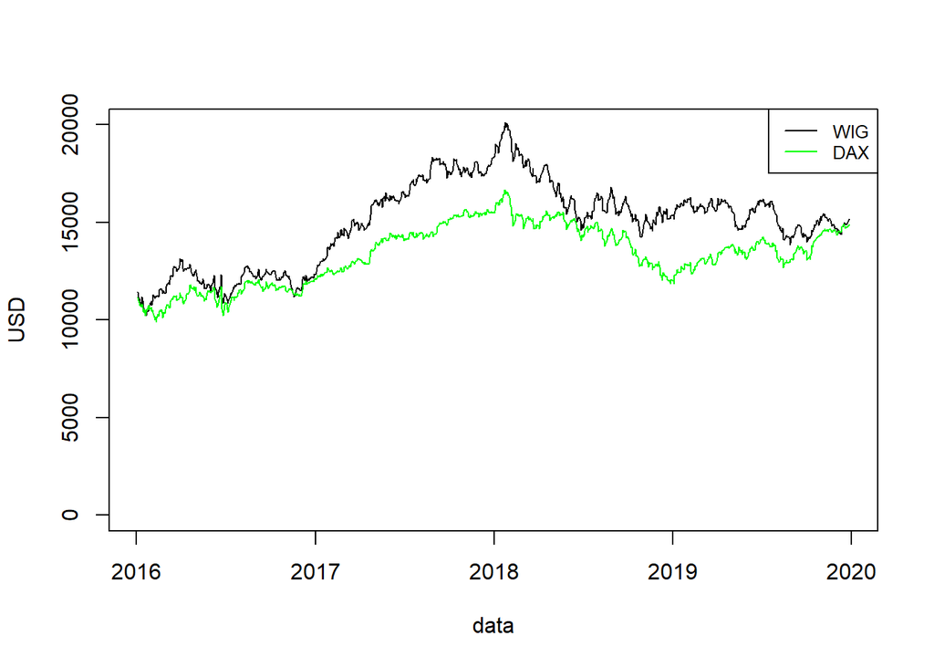

```r
plot(x = df_przed_interpolacja[,1], y = df_przed_interpolacja[,2], ylim = range(0:20000), type="l", xlab="data",ylab="USD") # WIG
lines(x = df_przed_interpolacja[,1], y=df_przed_interpolacja[,5], col = "green") # DAX
legend("topright", legend = c("WIG", "DAX"), col = c("black", "green"), lty = c(1, 1), cex = 0.8)
```

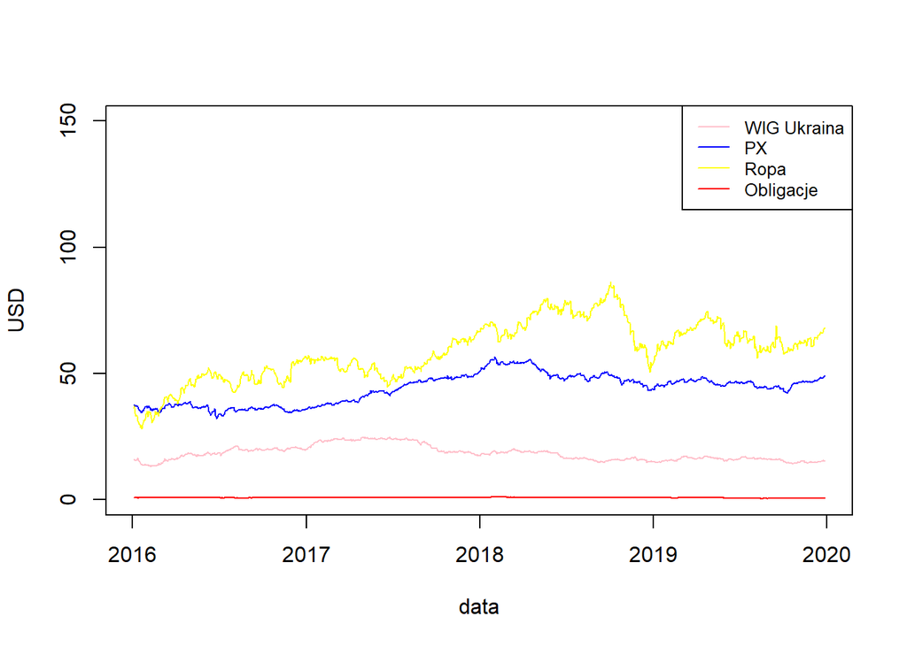

```r
plot(x = df_przed_interpolacja[,1], y=df_przed_interpolacja[,3], col = "pink", ylim = range(0:150), type="l", xlab="data",ylab="USD") # WIG Ukraina
lines(x = df_przed_interpolacja[,1], y=df_przed_interpolacja[,4], col = "blue") # PX
lines(x = df_przed_interpolacja[,1], y=df_przed_interpolacja[,6], col = "yellow") # Ropa
lines(x = df_przed_interpolacja[,1], y=df_przed_interpolacja[,7], col = "red") # Obligacje
legend("topright", legend = c("WIG Ukraina", "PX", "Ropa", "Obligacje"), col = c("pink", "blue", "yellow", "red"), lty = c(1, 1, 1, 1), cex = 0.8)
```

**Obliczenie stóp zwrotu**

```r
# przed
stopa_zwrotu_przed <- data.frame(matrix(0, nrow = nrow(df_przed_interpolacja),
                                        ncol = ncol(df_przed_interpolacja)))

stopa_zwrotu_przed[, 1] <- df_przed_interpolacja[, 1]

for (j in 2:ncol(stopa_zwrotu_przed)){
  for (i in 2:nrow(stopa_zwrotu_przed))
  {
  stopa_zwrotu_przed[i, j] <-
    (df_przed_interpolacja[i, j] - df_przed_interpolacja[i-1, j])/df_przed_interpolacja[i-1, j]
  }
}
stopa_zwrotu_przed <- stopa_zwrotu_przed[-1, ]
names(stopa_zwrotu_przed) <- names(df_przed_interpolacja)
rownames(stopa_zwrotu_przed) <- NULL
```

### Test stacjonarności

W celu sprawdzenia stacjonarności danych został przeprowadzony test Dickey’a-Fullera adf.test(), którego hipotezy przedstawiają się w sposób następujący:

*H0 : szereg jest niestacjonarny*

*H1 : szereg jest stacjonarny*

```r
# przed
adf.test(stopa_zwrotu_przed$WIG)
```

```
## Augmented Dickey-Fuller Test
## alternative: stationary
##
## Type 1: no drift no trend
##      lag   ADF p.value
## [1,]   0 -28.7    0.01
## [2,]   1 -22.3    0.01
## [3,]   2 -17.9    0.01
## [4,]   3 -16.1    0.01
## [5,]   4 -14.5    0.01
## [6,]   5 -13.3    0.01
## [7,]   6 -12.4    0.01
## Type 2: with drift no trend
##      lag   ADF p.value
## [1,]   0 -28.8    0.01
## [2,]   1 -22.3    0.01
## [3,]   2 -18.0    0.01
## [4,]   3 -16.1    0.01
## [5,]   4 -14.5    0.01
## [6,]   5 -13.4    0.01
## [7,]   6 -12.5    0.01
## Type 3: with drift and trend
##      lag   ADF p.value
## [1,]   0 -28.8    0.01
## [2,]   1 -22.4    0.01
## [3,]   2 -18.0    0.01
## [4,]   3 -16.2    0.01
## [5,]   4 -14.6    0.01
## [6,]   5 -13.4    0.01
## [7,]   6 -12.6    0.01
## ----
## Note: in fact, p.value = 0.01 means p.value <= 0.01
```

```r
adf.test(stopa_zwrotu_przed$WIG_Ukraina)
```

```
## Augmented Dickey-Fuller Test
## alternative: stationary
##
## Type 1: no drift no trend
##      lag   ADF p.value
## [1,]   0 -31.3    0.01
## [2,]   1 -21.2    0.01
## [3,]   2 -17.1    0.01
## [4,]   3 -15.4    0.01
## [5,]   4 -14.5    0.01
## [6,]   5 -12.9    0.01
## [7,]   6 -11.6    0.01
## Type 2: with drift no trend
##      lag   ADF p.value
## [1,]   0 -31.3    0.01
## [2,]   1 -21.2    0.01
## [3,]   2 -17.1    0.01
## [4,]   3 -15.4    0.01
## [5,]   4 -14.5    0.01
## [6,]   5 -12.8    0.01
## [7,]   6 -11.6    0.01
## Type 3: with drift and trend
##      lag   ADF p.value
## [1,]   0 -31.3    0.01
## [2,]   1 -21.3    0.01
## [3,]   2 -17.1    0.01
## [4,]   3 -15.5    0.01
## [5,]   4 -14.5    0.01
## [6,]   5 -12.9    0.01
## [7,]   6 -11.7    0.01
## ----
## Note: in fact, p.value = 0.01 means p.value <= 0.01
```

```r
adf.test(stopa_zwrotu_przed$PX)
```

```
## Augmented Dickey-Fuller Test
## alternative: stationary
##
## Type 1: no drift no trend
##      lag   ADF p.value
## [1,]   0 -30.1    0.01
## [2,]   1 -21.9    0.01
## [3,]   2 -17.2    0.01
## [4,]   3 -15.4    0.01
## [5,]   4 -15.2    0.01
## [6,]   5 -13.9    0.01
## [7,]   6 -13.1    0.01
## Type 2: with drift no trend
##      lag   ADF p.value
## [1,]   0 -30.1    0.01
## [2,]   1 -21.9    0.01
## [3,]   2 -17.2    0.01
## [4,]   3 -15.4    0.01
## [5,]   4 -15.2    0.01
## [6,]   5 -14.0    0.01
## [7,]   6 -13.2    0.01
## Type 3: with drift and trend
##      lag   ADF p.value
## [1,]   0 -30.1    0.01
## [2,]   1 -21.9    0.01
## [3,]   2 -17.2    0.01
## [4,]   3 -15.4    0.01
## [5,]   4 -15.2    0.01
## [6,]   5 -14.0    0.01
## [7,]   6 -13.2    0.01
## ----
## Note: in fact, p.value = 0.01 means p.value <= 0.01
```

```r
adf.test(stopa_zwrotu_przed$DAX)
```

```
## Augmented Dickey-Fuller Test
## alternative: stationary
##
## Type 1: no drift no trend
##      lag   ADF p.value
## [1,]   0 -31.5    0.01
## [2,]   1 -23.1    0.01
## [3,]   2 -18.2    0.01
## [4,]   3 -17.5    0.01
## [5,]   4 -17.0    0.01
## [6,]   5 -14.4    0.01
## [7,]   6 -12.8    0.01
## Type 2: with drift no trend
##      lag   ADF p.value
## [1,]   0 -31.5    0.01
## [2,]   1 -23.1    0.01
## [3,]   2 -18.2    0.01
## [4,]   3 -17.6    0.01
## [5,]   4 -17.1    0.01
## [6,]   5 -14.4    0.01
## [7,]   6 -12.8    0.01
## Type 3: with drift and trend
##      lag   ADF p.value
## [1,]   0 -31.5    0.01
## [2,]   1 -23.1    0.01
## [3,]   2 -18.2    0.01
## [4,]   3 -17.6    0.01
## [5,]   4 -17.1    0.01
## [6,]   5 -14.4    0.01
## [7,]   6 -12.9    0.01
## ----
## Note: in fact, p.value = 0.01 means p.value <= 0.01
```

```r
adf.test(stopa_zwrotu_przed$ROPA)
```

```
## Augmented Dickey-Fuller Test
## alternative: stationary
##
## Type 1: no drift no trend
##      lag   ADF p.value
## [1,]   0 -32.2    0.01
## [2,]   1 -22.0    0.01
## [3,]   2 -18.8    0.01
## [4,]   3 -16.1    0.01
## [5,]   4 -14.2    0.01
## [6,]   5 -13.2    0.01
## [7,]   6 -12.1    0.01
## Type 2: with drift no trend
##      lag   ADF p.value
## [1,]   0 -32.2    0.01
## [2,]   1 -22.1    0.01
## [3,]   2 -18.8    0.01
## [4,]   3 -16.2    0.01
## [5,]   4 -14.3    0.01
## [6,]   5 -13.3    0.01
## [7,]   6 -12.2    0.01
## Type 3: with drift and trend
##      lag   ADF p.value
## [1,]   0 -32.2    0.01
## [2,]   1 -22.1    0.01
## [3,]   2 -18.8    0.01
## [4,]   3 -16.2    0.01
## [5,]   4 -14.3    0.01
## [6,]   5 -13.3    0.01
## [7,]   6 -12.3    0.01
## ----
## Note: in fact, p.value = 0.01 means p.value <= 0.01
```

p.value wszędzie wynosi wynosi 0.01, czyli nie przekracza 5%, zatem odrzucamy hioptezę H0. Oznacza to, że stopy zwrotu są stacjonarne.

### Model VAR

Model wektorowej autoregresji podobnie jak w przypadku modeli AR nie posiada podziału na zmienne egzogeniczne oraz endogeniczne. Dzieje się tak, gdyż każda zmienna uwzględniona w modelu ma wpływ na pozostałe zmienne, a proces modelowania dotyczy każdej zmiennej.

#### Opóźnienie

Chcąc stworzyć model VAR należy wybrać rząd jego opóźnień.

```r
# przed
VARselect(as.matrix(stopa_zwrotu_przed[,-1]))
```

```
## $selection
## AIC(n)  HQ(n)  SC(n) FPE(n)
##      1      1      1      1
##
## $criteria
##                    1             2             3             4             5
## AIC(n) -5.417544e+01 -5.413872e+01 -5.412132e+01 -5.410497e+01 -5.408812e+01
## HQ(n)  -5.409833e+01 -5.399552e+01 -5.391203e+01 -5.382960e+01 -5.374665e+01
## SC(n)  -5.397238e+01 -5.376161e+01 -5.357016e+01 -5.337977e+01 -5.318886e+01
## FPE(n)  2.964202e-24  3.075075e-24  3.129112e-24  3.180784e-24  3.235022e-24
##                    6             7             8             9            10
## AIC(n) -5.405589e+01 -5.403207e+01 -5.399918e+01 -5.397332e+01 -5.394098e+01
## HQ(n)  -5.364834e+01 -5.355842e+01 -5.345944e+01 -5.336749e+01 -5.326906e+01
## SC(n)  -5.298259e+01 -5.278471e+01 -5.257777e+01 -5.237786e+01 -5.217148e+01
## FPE(n)  3.341233e-24  3.422163e-24  3.537103e-24  3.630442e-24  3.750610e-24
```

Wszystkie kryteria wskazują na wybór modelu z 1 opóźnieniem Wybrano opóźnienie 1

#### Budowanie modelu VAR

```r
# przed
model_przed <- VAR(stopa_zwrotu_przed[,-1], p = 1)
summary(model_przed)
```

```
##
## VAR Estimation Results:
## =========================
## Endogenous variables: WIG, WIG_Ukraina, PX, DAX, ROPA, obligacje
## Deterministic variables: const
## Sample size: 1028
## Log Likelihood: 19083.718
## Roots of the characteristic polynomial:
## 0.08438 0.08438 0.07603 0.04249 0.04249 0.02524
## Call:
## VAR(y = stopa_zwrotu_przed[, -1], p = 1)
##
##
## Estimation results for equation WIG:
## ====================================
## WIG = WIG.l1 + WIG_Ukraina.l1 + PX.l1 + DAX.l1 + ROPA.l1 + obligacje.l1 + const
##
##                  Estimate Std. Error t value Pr(>|t|)
## WIG.l1          0.0530630  0.0435828   1.218    0.224
## WIG_Ukraina.l1  0.0285611  0.0297966   0.959    0.338
## PX.l1           0.0322888  0.0543429   0.594    0.553
## DAX.l1          0.0623337  0.0469201   1.329    0.184
## ROPA.l1        -0.0244204  0.0181932  -1.342    0.180
## obligacje.l1    0.0135331  0.0245383   0.552    0.581
## const           0.0003247  0.0003485   0.932    0.352
##
##
## Residual standard error: 0.01116 on 1021 degrees of freedom
## Multiple R-Squared: 0.01721, Adjusted R-squared: 0.01144
## F-statistic:  2.98 on 6 and 1021 DF,  p-value: 0.006862
##
##
## Estimation results for equation WIG_Ukraina:
## ============================================
## WIG_Ukraina = WIG.l1 + WIG_Ukraina.l1 + PX.l1 + DAX.l1 + ROPA.l1 + obligacje.l1 + const
##
##                  Estimate Std. Error t value Pr(>|t|)
## WIG.l1         -5.722e-03  4.682e-02  -0.122  0.90276
## WIG_Ukraina.l1  1.570e-02  3.201e-02   0.491  0.62382
## PX.l1          -7.012e-02  5.838e-02  -1.201  0.22997
```

[output cut: 98 more lines]

```
## WIG         1.244e-04   2.806e-05 5.844e-05 7.174e-05 2.829e-05  3.278e-05
## WIG_Ukraina 2.806e-05   1.436e-04 1.469e-05 1.858e-05 2.141e-05 -2.812e-06
## PX          5.844e-05   1.469e-05 7.471e-05 5.325e-05 1.737e-05  2.872e-05
## DAX         7.174e-05   1.858e-05 5.325e-05 1.043e-04 2.503e-05  2.052e-05
## ROPA        2.829e-05   2.141e-05 1.737e-05 2.503e-05 3.684e-04  1.592e-05
## obligacje   3.278e-05  -2.812e-06 2.872e-05 2.052e-05 1.592e-05  2.119e-04
##
## Correlation matrix of residuals:
##                WIG WIG_Ukraina     PX    DAX    ROPA obligacje
## WIG         1.0000     0.20989 0.6060 0.6297 0.13214   0.20187
## WIG_Ukraina 0.2099     1.00000 0.1418 0.1518 0.09309  -0.01612
## PX          0.6060     0.14182 1.0000 0.6031 0.10468   0.22828
## DAX         0.6297     0.15176 0.6031 1.0000 0.12769   0.13799
## ROPA        0.1321     0.09309 0.1047 0.1277 1.00000   0.05698
## obligacje   0.2019    -0.01612 0.2283 0.1380 0.05698   1.00000
```

### Weryfikacja modelu

#### Przyczynowość w sensie Grangera

```r
# przed
granger_causality(model_przed)
```

```
##
## Granger Causality Test (Multivariate)
##
## F test and Wald χ² test based on VAR(1) model:
## ────────────────────────────────────────────────────────────────────────
##                                  F df1  df2     p     Chisq df     p
## ────────────────────────────────────────────────────────────────────────
##  ------------------------
##  WIG <= WIG_Ukraina           0.92   1 1021  .338      0.92  1  .338
##  WIG <= PX                    0.35   1 1021  .553      0.35  1  .552
##  WIG <= DAX                   1.76   1 1021  .184      1.76  1  .184
##  WIG <= ROPA                  1.80   1 1021  .180      1.80  1  .180
##  WIG <= obligacje             0.30   1 1021  .581      0.30  1  .581
##  WIG <= ALL                   1.16   5 1021  .328      5.79  5  .327
##  ------------------------
##  WIG_Ukraina <= WIG           0.12   2 1021  .885      0.24  2  .885
##  WIG_Ukraina <= PX            1.44   1 1021  .230      1.44  1  .230
##  WIG_Ukraina <= DAX           8.30   1 1021  .004 **   8.30  1  .004 **
##  WIG_Ukraina <= ROPA          0.02   1 1021  .884      0.02  1  .884
##  WIG_Ukraina <= obligacje     2.36   1 1021  .125      2.36  1  .125
##  WIG_Ukraina <= ALL           2.25   6 1021  .037 *   13.50  6  .036 *
##  ------------------------
##  PX <= WIG                    1.09   2 1021  .336      2.18  2  .336
##  PX <= WIG_Ukraina            0.53   1 1021  .465      0.53  1  .465
##  PX <= DAX                   14.55   1 1021 <.001 *** 14.55  1 <.001 ***
##  PX <= ROPA                   0.28   1 1021  .597      0.28  1  .597
##  PX <= obligacje              0.34   1 1021  .563      0.34  1  .562
##  PX <= ALL                    3.20   5 1021  .007 **  16.00  5  .007 **
##  ------------------------
##  DAX <= WIG                   0.60   2 1021  .550      1.20  2  .550
##  DAX <= WIG_Ukraina           0.45   1 1021  .505      0.45  1  .505
##  DAX <= PX                    0.13   1 1021  .716      0.13  1  .716
##  DAX <= ROPA                  0.39   1 1021  .534      0.39  1  .534
##  DAX <= obligacje             0.00   1 1021  .997      0.00  1  .997
##  DAX <= ALL                   0.40   5 1021  .850      1.99  5  .850
##  ------------------------
##  ROPA <= WIG                  1.46   2 1021  .233      2.92  2  .232
##  ROPA <= WIG_Ukraina          1.79   1 1021  .181      1.79  1  .181
##  ROPA <= PX                   3.19   1 1021  .074 .    3.19  1  .074 .
##  ROPA <= DAX                 10.53   1 1021  .001 **  10.53  1  .001 **
##  ROPA <= obligacje            1.25   1 1021  .264      1.25  1  .263
##  ROPA <= ALL                  5.91   5 1021 <.001 *** 29.57  5 <.001 ***
##  ------------------------
##  obligacje <= WIG             2.77   2 1021  .063 .    5.54  2  .063 .
##  obligacje <= WIG_Ukraina     2.67   1 1021  .102      2.67  1  .102
##  obligacje <= PX              0.95   1 1021  .331      0.95  1  .330
##  obligacje <= DAX             1.76   1 1021  .185      1.76  1  .184
##  obligacje <= ROPA            6.25   1 1021  .013 *    6.25  1  .012 *
##  obligacje <= ALL             2.83   5 1021  .015 *   14.16  5  .015 *
## ────────────────────────────────────────────────────────────────────────
```

## Okres po Covid

### Przygotowanie danych

**Wczytanie plików**

```r
# Polska
WIG_po <- read_csv("Dane/WIG_po.csv")
WIG_po <- WIG_po[,c(1,5)]
colnames(WIG_po) <- c('data','WIG_po')

ZLOTY_po <- read_csv("Dane/ZLOTY_po.csv")
ZLOTY_po <- ZLOTY_po[,c(1,5)]
colnames(ZLOTY_po) <- c('data','ZLOTY_po')

# Ukraina
WIG_ukraina_po <- read_csv("Dane/WIG_ukraina_po.csv")
WIG_ukraina_po <- WIG_ukraina_po[,c(1,5)]
colnames(WIG_ukraina_po) <- c('data','WIG_ukraina_po')

HRYWNA_po <- read_csv("Dane/HRYWNA_po.csv")
HRYWNA_po <- HRYWNA_po[,c(1,5)]
HRYWNA_po[,2] <- 1/HRYWNA_po[,2]
colnames(HRYWNA_po) <- c('data','HRYWNA_po')

# Czechy
PX_po <- read_csv("Dane/PX_po.csv")
PX_po <- PX_po[,c(1,5)]
colnames(PX_po) <- c('data','PX_po')

KORONA_po <- read_csv("Dane/KORONA_po.csv")
KORONA_po <- KORONA_po[,c(1,5)]
colnames(KORONA_po) <- c('data','KORONA_po')

# Niemcy
DAX_po <- read_csv("Dane/DAX_po.csv")
DAX_po <- DAX_po[,c(1,5)]
colnames(DAX_po) <- c('data','DAX_po')

EURO_po <- read_csv("Dane/EURO_po.csv")
EURO_po <- EURO_po[,c(1,5)]
colnames(EURO_po) <- c('data','EURO_po')

# ropa
ROPA_po <- read_delim("C:/Users/eweli/OneDrive/Desktop/AW/projekt2/dane/ROPA_po.csv",
    delim = ";", escape_double = FALSE, trim_ws = TRUE)
ROPA_po <- ROPA_po[,c(1,5)]
colnames(ROPA_po) <- c('data','ROPA_po')

# obligacje
obligacje_po <- read_csv("Dane/obligacje_po.csv")
obligacje_po <- obligacje_po[,c(1,5)]
colnames(obligacje_po) <- c('data','obligacje_po')
```

**Przewalutowanie na dolary**

```r
# POLSKA - WIG PLN na USD
df <- merge(x=WIG_po,y=ZLOTY_po,
          by="data", all.x=TRUE)
WIG_po_USD <- data.frame("data" = df[1], df[2]*df[3])
rm(df,WIG_po)

# UKRAINA - WIG Ukraina UAH na USD
df <- merge(x=WIG_ukraina_po,y=HRYWNA_po,
          by="data", all.x=TRUE)
WIG_ukraina_po_USD <- data.frame("data" = df[1], df[2]*df[3])
rm(df,WIG_ukraina_po,HRYWNA_po)

# Czechy PX CZK na USD
df <- merge(x=PX_po,y=KORONA_po,
          by="data", all.x=TRUE)
PX_po_USD <- data.frame("data" = df[1], df[2]*df[3])
rm(df,PX_po,KORONA_po)

# Niemcy DAX EUR na USD
df <- merge(x=DAX_po,y=EURO_po,
          by="data", all.x=TRUE)
DAX_po_USD <- data.frame("data" = df[1], df[2]*df[3])
rm(df,DAX_po,EURO_po)

# Ropa
ROPA_po$data <- as.Date(ROPA_po$data, format = "%d.%m.%Y")

# Obligacje PLN na USD
df <- merge(x=obligacje_po,y=ZLOTY_po,
          by="data", all.x=TRUE)
obligacje_po_USD <- data.frame("data" = df[1], df[2]*df[3])
rm(df,obligacje_po,ZLOTY_po)
```

**Łączenie wszystkich tabel w jedną**

```r
# po
df_po <- WIG_po_USD %>% full_join(WIG_ukraina_po_USD, by = "data")
df_po <- df_po %>% full_join(PX_po_USD, by = "data")
df_po <- df_po %>% full_join(DAX_po_USD, by = "data")
df_po <- df_po %>% full_join(ROPA_po, by = "data")
df_po <- df_po %>% full_join(obligacje_po_USD, by = "data")

rm(WIG_po_USD, WIG_ukraina_po_USD, PX_po_USD, DAX_po_USD, ROPA_po, obligacje_po_USD)
```

**Interpolacja liniowa**

Pnieważ jest dużo braków, to interpolacja liniowa nie zawsze sobie z nimi radzi, dlatego po zastosowaniu interpolacji musimy usunąć 2 wiersze w danych przed COVID W przypadku danych po 2020 roku musimy usunąć 1 wiersz.

```r
# po
# sortowanie danych wzgledem daty
df_po <- df_po[order(df_po$data), ]

df_po_interpolacja <- data.frame("data" = df_po$data,
                                 "WIG" = na.approx(df_po$WIG_po, na.rm = FALSE),
                                 "WIG_Ukraina" = na.approx(df_po$WIG_ukraina_po,
                                                           na.rm = FALSE),
                                 "PX" = na.approx(df_po$PX_po, na.rm = FALSE),
                                 "DAX" = na.approx(df_po$DAX_po, na.rm = FALSE),
                                 "ROPA" = na.approx(df_po$ROPA_po, na.rm = FALSE),
                                 "obligacje" = na.approx(df_po$obligacje_po, na.rm = FALSE))


df_po_interpolacja <- na.omit(df_po_interpolacja)
```

**Prezentacja fragmentu gotowych danych:**

```r
# po
knitr::kable(head(df_po_interpolacja), "simple", align ='llll')
```

|  | data | WIG | WIG_Ukraina | PX | DAX | ROPA | obligacje |
| --- | --- | --- | --- | --- | --- | --- | --- |
| 2 | 2020-01-03 | 15412.66 | 15.68257 | 49.38216 | 14754.81 | 68.58 | 0.5436210 |
| 3 | 2020-01-06 | 15359.50 | 15.77323 | 49.60986 | 14696.72 | 68.90 | 0.5567532 |
| 4 | 2020-01-07 | 15306.35 | 15.86390 | 49.37164 | 14745.01 | 68.27 | 0.5698854 |
| 5 | 2020-01-08 | 15116.67 | 15.95456 | 49.22371 | 14798.99 | 65.46 | 0.5802991 |
| 6 | 2020-01-09 | 15278.45 | 15.69379 | 49.56380 | 14988.29 | 65.32 | 0.5925920 |
| 7 | 2020-01-10 | 15426.57 | 16.15542 | 49.91266 | 14995.73 | 64.91 | 0.5938743 |

**Graficzna prezentacja wyników:**

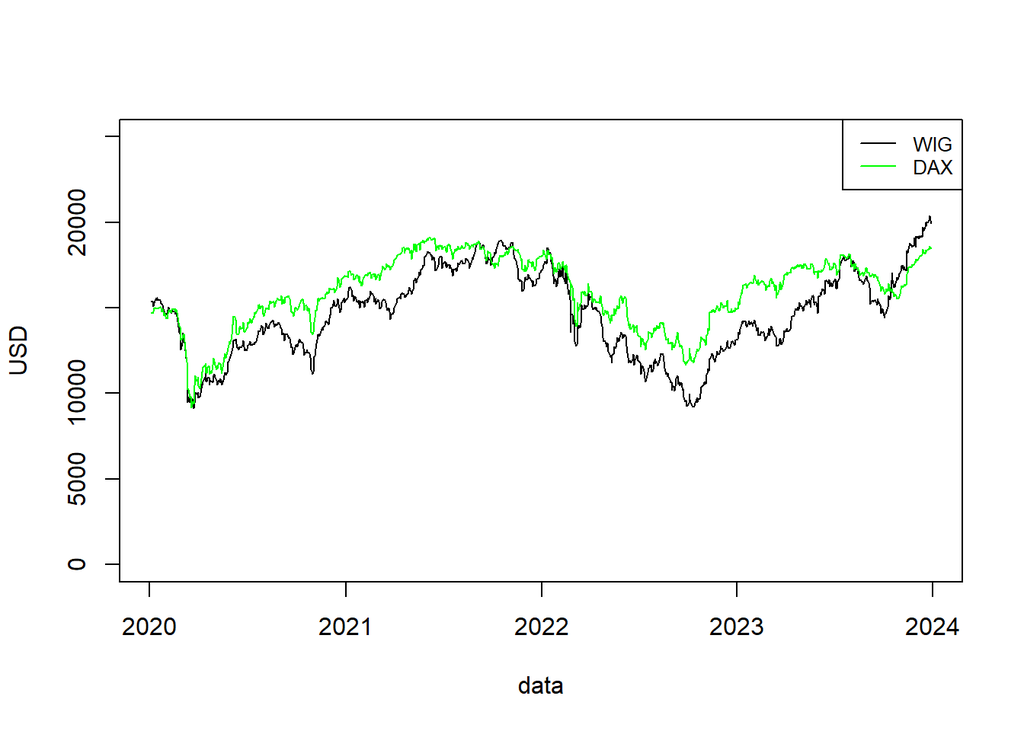

```r
plot(x = df_po_interpolacja[,1], y = df_po_interpolacja[,2], ylim = range(0:25000), type="l", xlab="data",ylab="USD") # WIG
lines(x = df_po_interpolacja[,1], y=df_po_interpolacja[,5], col = "green") # DAX
legend("topright", legend = c("WIG", "DAX"), col = c("black", "green"), lty = c(1, 1), cex = 0.8)
```

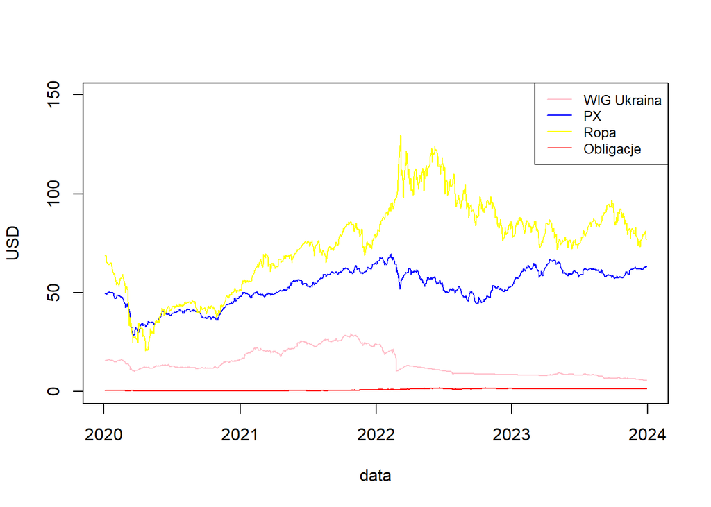

```r
plot(x = df_po_interpolacja[,1], y=df_po_interpolacja[,3], col = "pink", ylim = range(0:150), type="l", xlab="data",ylab="USD") # WIG Ukraina
lines(x = df_po_interpolacja[,1], y=df_po_interpolacja[,4], col = "blue") # PX
lines(x = df_po_interpolacja[,1], y=df_po_interpolacja[,6], col = "yellow") # Ropa
lines(x = df_po_interpolacja[,1], y=df_po_interpolacja[,7], col = "red") # Obligacje
legend("topright", legend = c("WIG Ukraina", "PX", "Ropa", "Obligacje"), col = c("pink", "blue", "yellow", "red"), lty = c(1, 1, 1, 1), cex = 0.8)
```

**Obliczenie stóp zwrotu**

```r
# po
stopa_zwrotu_po <- data.frame(matrix(0, nrow = nrow(df_po_interpolacja),
                                        ncol = ncol(df_po_interpolacja)))

stopa_zwrotu_po[, 1] <- df_po_interpolacja[, 1]

for (j in 2:ncol(stopa_zwrotu_po)){
  for (i in 2:nrow(stopa_zwrotu_po))
  {
  stopa_zwrotu_po[i, j] <-
    (df_po_interpolacja[i, j] - df_po_interpolacja[i-1, j])/df_po_interpolacja[i-1, j]
  }
}
stopa_zwrotu_po <- stopa_zwrotu_po[-1, ]
names(stopa_zwrotu_po) <- names(df_po_interpolacja)
rownames(stopa_zwrotu_po) <- NULL
```

### Test stacjonarności

W celu sprawdzenia stacjonarności danych został przeprowadzony test Dickey’a-Fullera adf.test(), którego hipotezy przedstawiają się w sposób następujący:

*H0 : szereg jest niestacjonarny*

*H1 : szereg jest stacjonarny*

```r
# po
adf.test(stopa_zwrotu_po$WIG)
```

```
## Augmented Dickey-Fuller Test
## alternative: stationary
##
## Type 1: no drift no trend
##      lag   ADF p.value
## [1,]   0 -29.9    0.01
## [2,]   1 -21.9    0.01
## [3,]   2 -17.3    0.01
## [4,]   3 -14.8    0.01
## [5,]   4 -12.5    0.01
## [6,]   5 -12.0    0.01
## [7,]   6 -11.0    0.01
## Type 2: with drift no trend
##      lag   ADF p.value
## [1,]   0 -29.9    0.01
## [2,]   1 -22.0    0.01
## [3,]   2 -17.3    0.01
## [4,]   3 -14.8    0.01
## [5,]   4 -12.5    0.01
## [6,]   5 -12.0    0.01
## [7,]   6 -11.0    0.01
## Type 3: with drift and trend
##      lag   ADF p.value
## [1,]   0 -29.9    0.01
## [2,]   1 -22.0    0.01
## [3,]   2 -17.3    0.01
## [4,]   3 -14.8    0.01
## [5,]   4 -12.5    0.01
## [6,]   5 -12.0    0.01
## [7,]   6 -11.0    0.01
## ----
## Note: in fact, p.value = 0.01 means p.value <= 0.01
```

```r
adf.test(stopa_zwrotu_po$WIG_Ukraina)
```

```
## Augmented Dickey-Fuller Test
## alternative: stationary
##
## Type 1: no drift no trend
##      lag   ADF p.value
## [1,]   0 -29.6    0.01
## [2,]   1 -20.5    0.01
## [3,]   2 -15.9    0.01
## [4,]   3 -14.4    0.01
## [5,]   4 -11.9    0.01
## [6,]   5 -11.7    0.01
## [7,]   6 -11.7    0.01
## Type 2: with drift no trend
##      lag   ADF p.value
## [1,]   0 -29.6    0.01
## [2,]   1 -20.5    0.01
## [3,]   2 -16.0    0.01
## [4,]   3 -14.4    0.01
## [5,]   4 -11.9    0.01
## [6,]   5 -11.8    0.01
## [7,]   6 -11.8    0.01
## Type 3: with drift and trend
##      lag   ADF p.value
## [1,]   0 -29.7    0.01
## [2,]   1 -20.6    0.01
## [3,]   2 -16.0    0.01
## [4,]   3 -14.5    0.01
## [5,]   4 -12.0    0.01
## [6,]   5 -11.8    0.01
## [7,]   6 -11.8    0.01
## ----
## Note: in fact, p.value = 0.01 means p.value <= 0.01
```

```r
adf.test(stopa_zwrotu_po$PX)
```

```
## Augmented Dickey-Fuller Test
## alternative: stationary
##
## Type 1: no drift no trend
##      lag   ADF p.value
## [1,]   0 -28.0    0.01
## [2,]   1 -18.8    0.01
## [3,]   2 -15.4    0.01
## [4,]   3 -13.3    0.01
## [5,]   4 -12.7    0.01
## [6,]   5 -13.4    0.01
## [7,]   6 -11.9    0.01
## Type 2: with drift no trend
##      lag   ADF p.value
## [1,]   0 -28.0    0.01
## [2,]   1 -18.8    0.01
## [3,]   2 -15.4    0.01
## [4,]   3 -13.3    0.01
## [5,]   4 -12.8    0.01
## [6,]   5 -13.4    0.01
## [7,]   6 -11.9    0.01
## Type 3: with drift and trend
##      lag   ADF p.value
## [1,]   0 -28.0    0.01
## [2,]   1 -18.8    0.01
## [3,]   2 -15.4    0.01
## [4,]   3 -13.3    0.01
## [5,]   4 -12.8    0.01
## [6,]   5 -13.4    0.01
## [7,]   6 -11.9    0.01
## ----
## Note: in fact, p.value = 0.01 means p.value <= 0.01
```

```r
adf.test(stopa_zwrotu_po$DAX)
```

```
## Augmented Dickey-Fuller Test
## alternative: stationary
##
## Type 1: no drift no trend
##      lag   ADF p.value
## [1,]   0 -31.5    0.01
## [2,]   1 -20.7    0.01
## [3,]   2 -17.8    0.01
## [4,]   3 -15.0    0.01
## [5,]   4 -13.0    0.01
## [6,]   5 -13.7    0.01
## [7,]   6 -11.9    0.01
## Type 2: with drift no trend
##      lag   ADF p.value
## [1,]   0 -31.5    0.01
## [2,]   1 -20.7    0.01
## [3,]   2 -17.8    0.01
## [4,]   3 -15.0    0.01
## [5,]   4 -13.0    0.01
## [6,]   5 -13.7    0.01
## [7,]   6 -11.9    0.01
## Type 3: with drift and trend
##      lag   ADF p.value
## [1,]   0 -31.5    0.01
## [2,]   1 -20.7    0.01
## [3,]   2 -17.8    0.01
## [4,]   3 -15.0    0.01
## [5,]   4 -13.0    0.01
## [6,]   5 -13.7    0.01
## [7,]   6 -11.9    0.01
## ----
## Note: in fact, p.value = 0.01 means p.value <= 0.01
```

```r
adf.test(stopa_zwrotu_po$ROPA)
```

```
## Augmented Dickey-Fuller Test
## alternative: stationary
##
## Type 1: no drift no trend
##      lag   ADF p.value
## [1,]   0 -30.7    0.01
## [2,]   1 -22.7    0.01
## [3,]   2 -18.3    0.01
## [4,]   3 -15.2    0.01
## [5,]   4 -14.2    0.01
## [6,]   5 -13.3    0.01
## [7,]   6 -12.3    0.01
## Type 2: with drift no trend
##      lag   ADF p.value
## [1,]   0 -30.7    0.01
## [2,]   1 -22.7    0.01
## [3,]   2 -18.3    0.01
## [4,]   3 -15.2    0.01
## [5,]   4 -14.2    0.01
## [6,]   5 -13.3    0.01
## [7,]   6 -12.3    0.01
## Type 3: with drift and trend
##      lag   ADF p.value
## [1,]   0 -30.7    0.01
## [2,]   1 -22.7    0.01
## [3,]   2 -18.3    0.01
## [4,]   3 -15.2    0.01
## [5,]   4 -14.2    0.01
## [6,]   5 -13.3    0.01
## [7,]   6 -12.3    0.01
## ----
## Note: in fact, p.value = 0.01 means p.value <= 0.01
```

p.value wszędzie wynosi wynosi 0.01, czyli nie przekracza 5%, zatem odrzucamy hioptezę H0. Oznacza to, że stopy zwrotu są stacjonarne.

### Model VAR

Model wektorowej autoregresji podobnie jak w przypadku modeli AR nie posiada podziału na zmienne egzogeniczne oraz endogeniczne. Dzieje się tak, gdyż każda zmienna uwzględniona w modelu ma wpływ na pozostałe zmienne, a proces modelowania dotyczy każdej zmiennej.

#### Opóźnienie

Chcąc stworzyć model VAR należy wybrać rząd jego opóźnień.

```r
# po
VARselect(as.matrix(stopa_zwrotu_po[,-1]))
```

```
## $selection
## AIC(n)  HQ(n)  SC(n) FPE(n)
##      8      1      1      8
##
## $criteria
##                    1             2             3             4             5
## AIC(n) -4.898097e+01 -4.902126e+01 -4.900880e+01 -4.899946e+01 -4.899006e+01
## HQ(n)  -4.890406e+01 -4.887842e+01 -4.880003e+01 -4.872476e+01 -4.864944e+01
## SC(n)  -4.877839e+01 -4.864503e+01 -4.845893e+01 -4.827595e+01 -4.809291e+01
## FPE(n)  5.343613e-22  5.132656e-22  5.197084e-22  5.246033e-22  5.295838e-22
##                    6             7             8             9            10
## AIC(n) -4.900292e+01 -4.903214e+01 -4.903732e+01 -4.902247e+01 -4.901196e+01
## HQ(n)  -4.859637e+01 -4.855966e+01 -4.849893e+01 -4.841815e+01 -4.834171e+01
## SC(n)  -4.793212e+01 -4.778770e+01 -4.761924e+01 -4.743075e+01 -4.724659e+01
## FPE(n)  5.228614e-22  5.078593e-22  5.053033e-22  5.129573e-22  5.184974e-22
```

Kryterium AIC i FPE wskazuje na oóźnienie 8, natomiast HQ i SC na opóźnienie 1. Wybrano opóźnienie 1

#### Budowanie modelu VAR

```r
# po
model_po <- VAR(stopa_zwrotu_po[,-1], p = 1)
summary(model_po)
```

```
##
## VAR Estimation Results:
## =========================
## Endogenous variables: WIG, WIG_Ukraina, PX, DAX, ROPA, obligacje
## Deterministic variables: const
## Sample size: 1031
## Log Likelihood: 16529.866
## Roots of the characteristic polynomial:
## 0.1787 0.1364 0.1364 0.08547 0.07738 0.07738
## Call:
## VAR(y = stopa_zwrotu_po[, -1], p = 1)
##
##
## Estimation results for equation WIG:
## ====================================
## WIG = WIG.l1 + WIG_Ukraina.l1 + PX.l1 + DAX.l1 + ROPA.l1 + obligacje.l1 + const
##
##                Estimate Std. Error t value Pr(>|t|)
## WIG.l1          0.08864    0.05170   1.714   0.0867 .
## WIG_Ukraina.l1 -0.07041    0.03012  -2.338   0.0196 *
## PX.l1          -0.00308    0.05848  -0.053   0.9580
## DAX.l1          0.02416    0.06161   0.392   0.6950
## ROPA.l1         0.03376    0.02001   1.687   0.0918 .
## obligacje.l1   -0.04088    0.02214  -1.847   0.0651 .
## const           0.00035    0.00056   0.625   0.5321
## ---
## Signif. codes:  0 '***' 0.001 '**' 0.01 '*' 0.05 '.' 0.1 ' ' 1
##
##
## Residual standard error: 0.01793 on 1024 degrees of freedom
## Multiple R-Squared: 0.01601, Adjusted R-squared: 0.01025
## F-statistic: 2.777 on 6 and 1024 DF,  p-value: 0.01104
##
##
## Estimation results for equation WIG_Ukraina:
## ============================================
## WIG_Ukraina = WIG.l1 + WIG_Ukraina.l1 + PX.l1 + DAX.l1 + ROPA.l1 + obligacje.l1 + const
##
##                  Estimate Std. Error t value Pr(>|t|)
## WIG.l1          0.0757211  0.0594817   1.273   0.2033
```

[output cut: 102 more lines]

```
## WIG         3.216e-04   1.624e-04 1.671e-04 2.118e-04 1.172e-04 8.635e-05
## WIG_Ukraina 1.624e-04   4.256e-04 9.443e-05 9.931e-05 5.000e-05 5.322e-05
## PX          1.671e-04   9.443e-05 2.013e-04 1.594e-04 9.276e-05 5.802e-05
## DAX         2.118e-04   9.931e-05 1.594e-04 2.417e-04 9.307e-05 5.051e-05
## ROPA        1.172e-04   5.000e-05 9.276e-05 9.307e-05 8.488e-04 1.468e-04
## obligacje   8.635e-05   5.322e-05 5.802e-05 5.051e-05 1.468e-04 6.568e-04
##
## Correlation matrix of residuals:
##                WIG WIG_Ukraina     PX    DAX    ROPA obligacje
## WIG         1.0000     0.43885 0.6568 0.7596 0.22440    0.1879
## WIG_Ukraina 0.4388     1.00000 0.3226 0.3096 0.08319    0.1007
## PX          0.6568     0.32261 1.0000 0.7225 0.22439    0.1596
## DAX         0.7596     0.30962 0.7225 1.0000 0.20547    0.1268
## ROPA        0.2244     0.08319 0.2244 0.2055 1.00000    0.1967
## obligacje   0.1879     0.10066 0.1596 0.1268 0.19666    1.0000
```

### Weryfikacja modelu

#### Przyczynowość w sensie Grangera

```r
# po
granger_causality(model_po)
```

```
##
## Granger Causality Test (Multivariate)
##
## F test and Wald χ² test based on VAR(1) model:
## ────────────────────────────────────────────────────────────────────────
##                                  F df1  df2     p     Chisq df     p
## ────────────────────────────────────────────────────────────────────────
##  ------------------------
##  WIG <= WIG_Ukraina           5.47   1 1024  .020 *    5.47  1  .019 *
##  WIG <= PX                    0.00   1 1024  .958      0.00  1  .958
##  WIG <= DAX                   0.15   1 1024  .695      0.15  1  .695
##  WIG <= ROPA                  2.85   1 1024  .092 .    2.85  1  .092 .
##  WIG <= obligacje             3.41   1 1024  .065 .    3.41  1  .065 .
##  WIG <= ALL                   2.32   5 1024  .042 *   11.58  5  .041 *
##  ------------------------
##  WIG_Ukraina <= WIG           3.76   2 1024  .024 *    7.52  2  .023 *
##  WIG_Ukraina <= PX            0.18   1 1024  .671      0.18  1  .671
##  WIG_Ukraina <= DAX           1.82   1 1024  .177      1.82  1  .177
##  WIG_Ukraina <= ROPA          1.63   1 1024  .202      1.63  1  .201
##  WIG_Ukraina <= obligacje     2.47   1 1024  .116      2.47  1  .116
##  WIG_Ukraina <= ALL           2.02   6 1024  .060 .   12.15  6  .059 .
##  ------------------------
##  PX <= WIG                    2.09   2 1024  .124      4.18  2  .124
##  PX <= WIG_Ukraina            4.18   1 1024  .041 *    4.18  1  .041 *
##  PX <= DAX                    0.04   1 1024  .848      0.04  1  .848
##  PX <= ROPA                   9.05   1 1024  .003 **   9.05  1  .003 **
##  PX <= obligacje             11.15   1 1024 <.001 *** 11.15  1 <.001 ***
##  PX <= ALL                    4.47   5 1024 <.001 *** 22.33  5 <.001 ***
##  ------------------------
##  DAX <= WIG                   2.28   2 1024  .103      4.55  2  .103
##  DAX <= WIG_Ukraina           4.32   1 1024  .038 *    4.32  1  .038 *
##  DAX <= PX                    9.41   1 1024  .002 **   9.41  1  .002 **
##  DAX <= ROPA                  8.96   1 1024  .003 **   8.96  1  .003 **
##  DAX <= obligacje             3.34   1 1024  .068 .    3.34  1  .068 .
##  DAX <= ALL                   5.03   5 1024 <.001 *** 25.16  5 <.001 ***
##  ------------------------
##  ROPA <= WIG                  0.11   2 1024  .891      0.23  2  .891
##  ROPA <= WIG_Ukraina          0.18   1 1024  .671      0.18  1  .671
##  ROPA <= PX                   0.08   1 1024  .782      0.08  1  .782
##  ROPA <= DAX                  2.55   1 1024  .111      2.55  1  .110
##  ROPA <= obligacje            2.36   1 1024  .125      2.36  1  .124
##  ROPA <= ALL                  1.58   5 1024  .164      7.88  5  .163
##  ------------------------
##  obligacje <= WIG             3.75   2 1024  .024 *    7.50  2  .024 *
##  obligacje <= WIG_Ukraina     2.09   1 1024  .148      2.09  1  .148
##  obligacje <= PX              0.15   1 1024  .700      0.15  1  .700
##  obligacje <= DAX             0.07   1 1024  .797      0.07  1  .797
##  obligacje <= ROPA            2.82   1 1024  .094 .    2.82  1  .093 .
##  obligacje <= ALL             3.21   5 1024  .007 **  16.03  5  .007 **
## ────────────────────────────────────────────────────────────────────────
```